# Assignment_2

### Questions

**1. Age = 40, Experience = 10, Income = 84, Family = 2, CCAvg = 2, Education_1 = 0, Education_2 = 1, Education_3 = 0, Mortgage = 0, Securities Account = 0, CD Account = 0, Online = 1, and Credit Card = 1. Perform a k-NN classification with all predictors except ID and ZIP code using k = 1. Remember to transform categorical predictors with more than two categories into dummy variables first. Specify the success class as 1 (loan acceptance), and use the default cutoff value of 0.5. How would this customer be classified?**

**Now create new customer data based on above question**

```r
new_customer = data.frame(
  Age = 40,
  Experience = 10,
  Income = 84,
  Family = 2,
  CCAvg = 2,
  Education.1 = 0,
  Education.2 = 1,
  Education.3 = 0,
  Mortgage = 0,
  Securities.Account = 0,
  CD.Account = 0,
  Online = 1,
  CreditCard = 1
)
```

**Normalizing new customer data**

```r
new.cust.norm = predict(norm.values, new_customer)
```

**Now predict using KNN**

```r
knn.predict = class::knn(train = train.norm.df, test = new.cust.norm,
                         cl = train.df$Personal.Loan, k = 1)
knn.predict
```

```
## [1] 0
## Levels: 0 1
```

**2. What is a choice of k that balances between overfitting and ignoring the predictor information?**

```r
accuracy.df = data.frame(k = seq(1, 15, 1), overallaccuracy = rep(0, 15))
for(i in 1:15) {
  knn.pred = class::knn(train = train.norm.df,
                         test = valid.norm.df,
                         cl = train.df$Personal.Loan, k = i)
  accuracy.df[i, 2] = confusionMatrix(knn.pred,
                                       as.factor(valid.df$Personal.Loan),positive = "1")$overall[1]
}

which(accuracy.df[,2] == max(accuracy.df[,2]))
```

```
## [1] 3
```

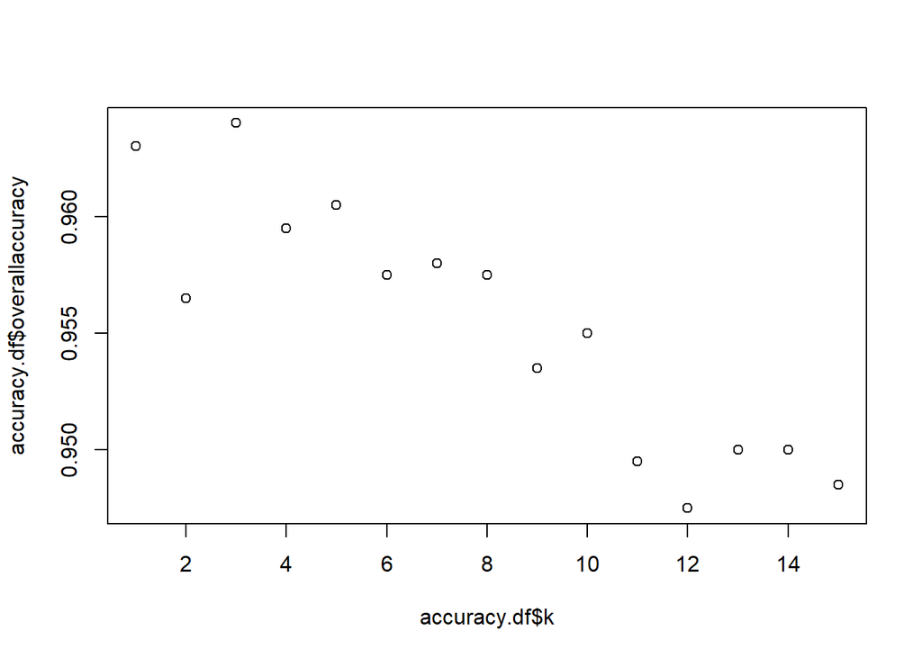

```r
plot(accuracy.df$k,accuracy.df$overallaccuracy)
```

***

**3. Show the confusion matrix for the validation data that results from using the best k.**

```r
best_knn_pred = class::knn(train = train.norm.df,
                            test = valid.norm.df,
                          cl = train.df$Personal.Loan, k = 3)
```

**Now create confusion matrix**

```r
confusion_matrix = confusionMatrix(best_knn_pred,
                                     as.factor(valid.df$Personal.Loan),
                                     positive = "1")
confusion_matrix
```

```
## Confusion Matrix and Statistics
##
##           Reference
## Prediction    0    1
##          0 1786   63
##          1    9  142
##
##                Accuracy : 0.964
##                  95% CI : (0.9549, 0.9717)
##     No Information Rate : 0.8975
##     P-Value [Acc > NIR] : < 2.2e-16
##
##                   Kappa : 0.7785
##
##  Mcnemar's Test P-Value : 4.208e-10
##
##             Sensitivity : 0.6927
##             Specificity : 0.9950
##          Pos Pred Value : 0.9404
##          Neg Pred Value : 0.9659
##              Prevalence : 0.1025
##          Detection Rate : 0.0710
##    Detection Prevalence : 0.0755
##       Balanced Accuracy : 0.8438
##
##        'Positive' Class : 1
##
```

**4.Consider the following customer: Age = 40, Experience = 10, Income = 84,Family = 2, CCAvg = 2, Education_1 = 0, Education_2 = 1, Education_3 = 0, Mortgage = 0, Securities Account = 0, CD Account = 0, Online = 1 and Credit Card = 1. Classify the customer using the best k.**

```r
new_customer_knn_pred = class::knn(train = train.norm.df,
                                    test = new.cust.norm,
                                    cl = train.df$Personal.Loan, k = 3)

new_customer_knn_pred
```

```
## [1] 0
## Levels: 0 1
```

**5. Repartition the data, this time into training, validation, and test sets (50% : 30% : 20%). Apply the k-NN method with the k chosen above. Compare the confusion matrix of the test set with that of the training and validation sets. Comment on the differences and their reason.**

**To ensure we get sample if we re run the code**

```r
set.seed(1)
```

**Now split the data**

```r
training_set = sample(nrow(data_m.df), 0.5 * nrow(data_m.df))

validation_set = sample(setdiff(1:nrow(data_m.df), training_set), 0.3 * nrow(data_m.df))

test_set = setdiff(1:nrow(data_m.df), union(training_set, validation_set))

train.df = data_m.df[training_set,]

valid.df = data_m.df[validation_set,]

test.df = data_m.df[test_set,]
```

**Now normalize the data**

```r
train.norm.df = train.df[,-10]

valid.norm.df = valid.df[,-10]

test.norm.df = test.df[,-10]

norm.values = preProcess(train.df[, -10], method=c("center", "scale")) # Z Normalize

train.norm.df = predict(norm.values, train.norm.df)

valid.norm.df = predict(norm.values, valid.norm.df)

test.norm.df = predict(norm.values, test.norm.df)
```

**Now predict using KNN**

```r
training_knn_pred = class::knn(train = train.norm.df,
                           test = train.norm.df,
                           cl = train.df$Personal.Loan,
                           k = 3)

validation_knn_pred = class::knn(train = train.norm.df,
                           test = valid.norm.df,
                           cl = train.df$Personal.Loan,
                           k = 3)

test_knn_pred = class::knn(train = train.norm.df,
                     test = test.norm.df,
                     cl = train.df$Personal.Loan,
                     k = 3)
```

**Confusion Matrix for Training set**

```r
training_confusion_matrix = confusionMatrix(training_knn_pred,
                                               as.factor(train.df$Personal.Loan),
                                               positive = "1")

training_confusion_matrix
```

```
## Confusion Matrix and Statistics
##
##           Reference
## Prediction    0    1
##          0 2263   54
##          1    5  178
##
##                Accuracy : 0.9764
##                  95% CI : (0.9697, 0.982)
##     No Information Rate : 0.9072
##     P-Value [Acc > NIR] : < 2.2e-16
##
##                   Kappa : 0.8452
##
##  Mcnemar's Test P-Value : 4.129e-10
##
##             Sensitivity : 0.7672
##             Specificity : 0.9978
##          Pos Pred Value : 0.9727
##          Neg Pred Value : 0.9767
##              Prevalence : 0.0928
##          Detection Rate : 0.0712
##    Detection Prevalence : 0.0732
##       Balanced Accuracy : 0.8825
##
##        'Positive' Class : 1
##
```

**Confusion Matrix for Validation set**

```r
validation_confusion_matrix = confusionMatrix(validation_knn_pred,
                                               as.factor(valid.df$Personal.Loan),
                                               positive = "1")

validation_confusion_matrix
```

```
## Confusion Matrix and Statistics
##
##           Reference
## Prediction    0    1
##          0 1358   42
##          1    6   94
##
##                Accuracy : 0.968
##                  95% CI : (0.9578, 0.9763)
##     No Information Rate : 0.9093
##     P-Value [Acc > NIR] : < 2.2e-16
##
##                   Kappa : 0.7797
##
##  Mcnemar's Test P-Value : 4.376e-07
##
##             Sensitivity : 0.69118
##             Specificity : 0.99560
##          Pos Pred Value : 0.94000
##          Neg Pred Value : 0.97000
##              Prevalence : 0.09067
##          Detection Rate : 0.06267
##    Detection Prevalence : 0.06667
##       Balanced Accuracy : 0.84339
##
##        'Positive' Class : 1
##
```

**Confusion Matrix for Test set**

```r
test_confusion_matrix = confusionMatrix(test_knn_pred,
                                         as.factor(test.df$Personal.Loan),
                                         positive = "1")


test_confusion_matrix
```

```
## Confusion Matrix and Statistics
##
##           Reference
## Prediction   0   1
##          0 884  35
##          1   4  77
##
##                Accuracy : 0.961
##                  95% CI : (0.9471, 0.9721)
##     No Information Rate : 0.888
##     P-Value [Acc > NIR] : < 2.2e-16
##
##                   Kappa : 0.777
##
##  Mcnemar's Test P-Value : 1.556e-06
##
##             Sensitivity : 0.6875
##             Specificity : 0.9955
##          Pos Pred Value : 0.9506
##          Neg Pred Value : 0.9619
##              Prevalence : 0.1120
##          Detection Rate : 0.0770
##    Detection Prevalence : 0.0810
##       Balanced Accuracy : 0.8415
##
##        'Positive' Class : 1
##
```

## Differences and Their Reasons for Validation and Test Confusion Matrix

## Differences

**Test VS Train**

*Accuracy:* Accuracy of Training Confusion matrix(0.9764) is slightly higher than Test Confusion matrix(0.961).

*Sensitivity(True Positive Rate):* Training Confusion Matrix has a higher sensitivity (0.7672) compared to Test Confusion Matrix (0.6875).

*Specificity(True Negative Rate):* Both matrices have similar specificity values and they are both very high. Training Confusion Matrix has a slightly higher specificity (0.9978) compared to Test Confusion Matrix (0.9955).

*Precision:* The precision in Training Confusion Matrix (0.9727) has a higher value that Test Confusion Matrix (0.9506).

**Test VS Validation**

*Accuracy:* Accuracy of Validation Confusion matrix(0.968) is slightly higher than Test Confusion matrix(0.961).

*Sensitivity(True Positive Rate):* Both matrices have similar sensitivity values but Validation Confusion Matrix has a slightly higher sensitivity (0.69118) compared to Test Confusion Matrix (0.6875).

*Specificity(True Negative Rate):* Both matrices have similar specificity values and they are both very high. Validation Confusion Matrix has a slightly higher specificity (0.99560) compared to Test Confusion Matrix (0.9955).

*Precision:* The precision in Test Confusion Matrix (0.9506) is higher Validation Confusion Matrix (0.94000).

## Reasons

*Dataset:* Since, we used different dataset size for Training, validation and test.Also, higher values in confusion matrix for Training data is because we used Same dataset in test argument for Train KNN.